# An introduction to RETRO

Kaitlyn Ramesh

April 25, 2025

## 1. Overview

In this vignette, we will discuss how to use the package RETRO to infer the pseudotime for simulated time-series scRNA-seq data. RETRO provides a workflow for incorporating sampling time in trajectory inference such that the outputted pseudotime is consistent with the dynamics of cellular transitions. We will also show how RETRO allows for capturing both branching and cyclic trajectories.

## 2. Analysis

```r
library(RETRO)
```

We will make use of a few packages for plotting (`ggpubr`, `ggplot2`) to aid in visualization, as well as packages for parallelization (`doParallel`, `parallel`) to expedite steps in RETRO.

```r
library(ggplot2) # plotting
library(ggpubr) # plotting
library(doParallel)
library(parallel)
```

### 2.1 Preprocessed data

```r
# Example 2: Bifurcating lineages
data("scd_bifurcation")
names(scd_bifurcation) # (1) log-normalized count matrix, (2) discrete sampling time, (3) ground-truth continuous developmental time
```

```
#> [1] "Counts"    "Time"      "Time_Cont"
```

```r
# Example 1: Single lineage, two cycles
data("scd_twocycles")

# Time information (example 1 bifurcation)
time = scd_bifurcation$Time
print(sort(unique(time)))
```

```
#>  [1]  1  2  3  4  5  6  7  8  9 10
```

We will be looking at two examples of time-series scRNA-seq in this tutorial, both simulated cases generated using the `dyntoy` library from dynverse. The first example is a bifurcation where a starting population of cells splits into two terminal cell types. We contain log-transformed counts in `scd_bifurcation[["Counts]]`, discrete experimental time in `scd_bifurcation[["Time"]]`, and ground truth continuous time in `scd_bifurcation[["Time_Cont"]]`.  
The second example forms two cycles, showing that the cells return to earlier states of gene expression at later time points. Because `dyntoy::generate_dataset()` can only form a single cycle, we modified its simulation to become two overlapping cycles. As a result, there is no ground-truth developmental time for this case.

### 2.2 Dimensionality reduction

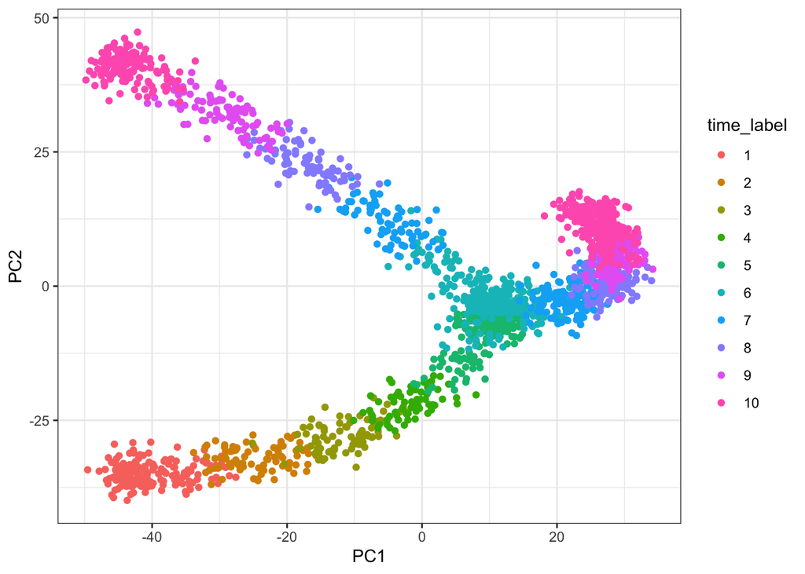

```r
# PCA analysis
pca = prcomp(scd_bifurcation$Counts, center=T)

time_label = as.factor(time) # factor for coloring
ggplot(as.data.frame(pca$x), aes(x=PC1,y=PC2,colour=time_label)) + geom_point() + theme_bw()
```

For this first example, we will use PCA for dimensionality reduction. We recommend linear methods for dimensionality reduction although RETRO is compatible with UMAP coordinates as an input.

## 3. RETRO

### 3.1 Path detection

#### 3.1.1 Integrating gene expression and time information in distance

```r
lambda = 1
time <- scd_bifurcation$Time

scd_bifurcation$PCA = pca
coordinates <- weight_coord(scd_bifurcation, weight = lambda)
coordinates_uw <- weight_coord(scd_bifurcation, weight = 0)
```

#### 3.1.2 Iterative clustering to identify global lineages

We start off analysis with RETRO by creating `retro_obj`, which stores the coordinate information, sampling time. We also set the desired cluster range `k_range`. For each K, we iteratively cluster the cells a number of times set by the parameter `num_scores`. By default it is ~100, but for the purposes of this vignette, we will limit the runs to 20.  
Using the function `set_RETRO_class()`, we establish an RETRO object `retro_obj`, which is important for storing parameters, inputs, intermediates, and outputs all involved in conducting pseudotime analysis with RETRO.

```r
k_range = seq(8,13) # set range of clusters
num_scores = 20

retro_obj = set_RETRO_class(coordinates=coordinates,
                            coordinates_uw=coordinates_uw,
                            k_range = k_range,
                            time=time)

ncores <- parallel::detectCores()
registerDoParallel(cores=ncores)
retro_obj = scoring(retro_obj, k_range, num_scores)
```

#### 3.1.3 Visualize distribution of scores over K clusters

Here, we can visualize results from the MST generation and scoring steps. We can see that with more clusters, the score decreases, indicating that the MSTs fit closer along the projection of cells. This makes sense as for this bifurcating structure, more clusters will increase the resolution of the MST structure.

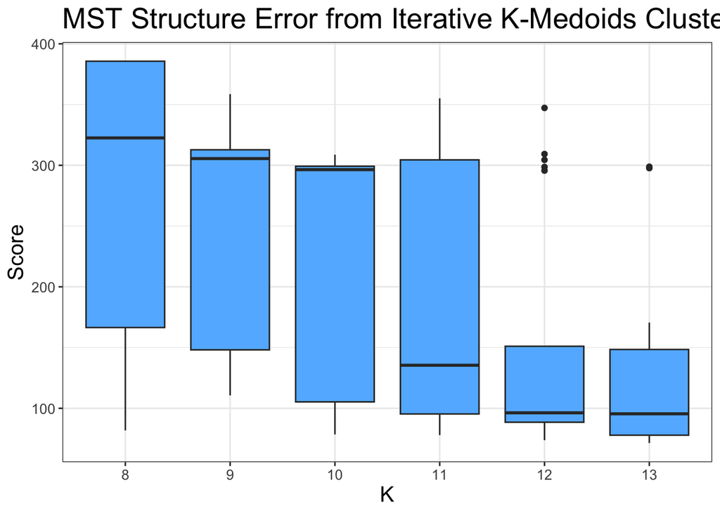

```r
boxplot_scoring(retro_obj)
```

#### 3.1.4 Identify global lineages across the ensemble of MSTs

The parameter `percent`, default at 0.05, is looks at the top 5% of high performing MSTs to determine the optimal number of lineages, as well as group cells based on their lineage. `get_num_lineages` is an important function for inferring the global trajectories underlying the data based on results of the iterative clustering and MST generation steps.

```r
retro_obj <- get_num_lineages(retro_obj, percent=0.05)
```

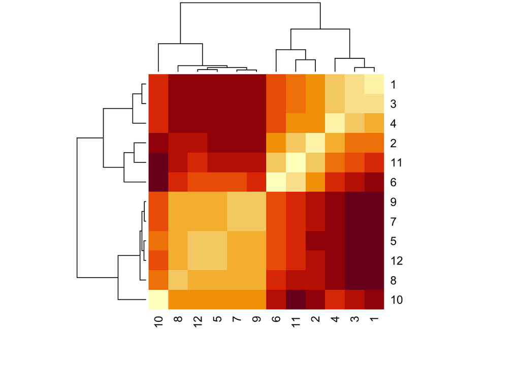

```
#> [1] "# of lineages (determined by Louvain clustering): 2"
```

### 3.2 Pseudotime estimation

#### 3.2.1 Spline fitting

```r
retro_obj <- get_bezier_curve(retro_obj)
retro_obj <- get_mapped_cells(retro_obj)
```

#### 3.2.2 Fitting real time-calibrated pseudotime

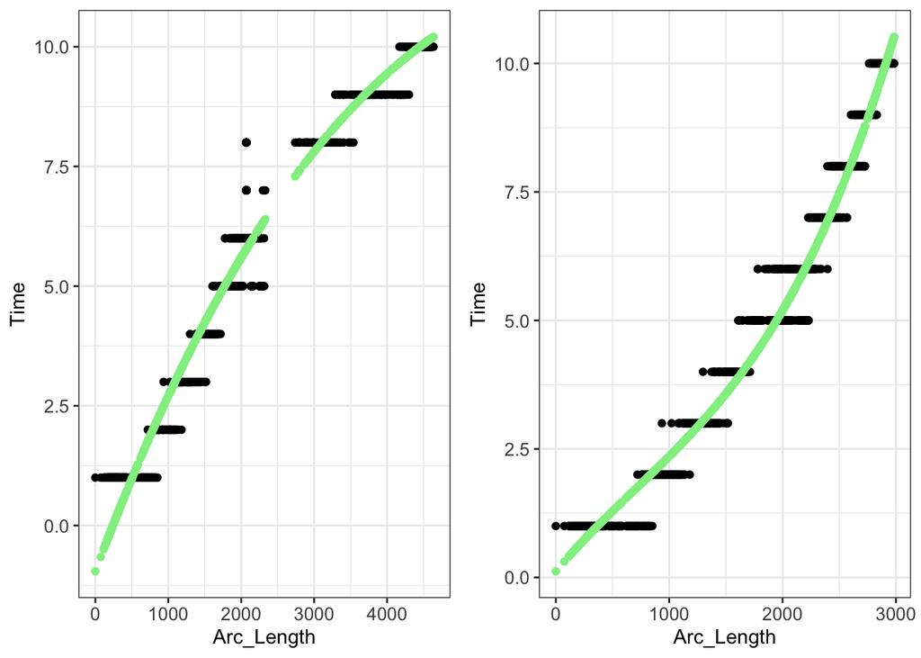

```r
retro_obj = pseudotime_fit(retro_obj)

lin_1 = retro_obj@pseudotime_graph[[1]]
lin_2 = retro_obj@pseudotime_graph[[2]]

ggarrange(lin_1, lin_2, ncol=2)
```

### 3.3 Pseudotime visualization

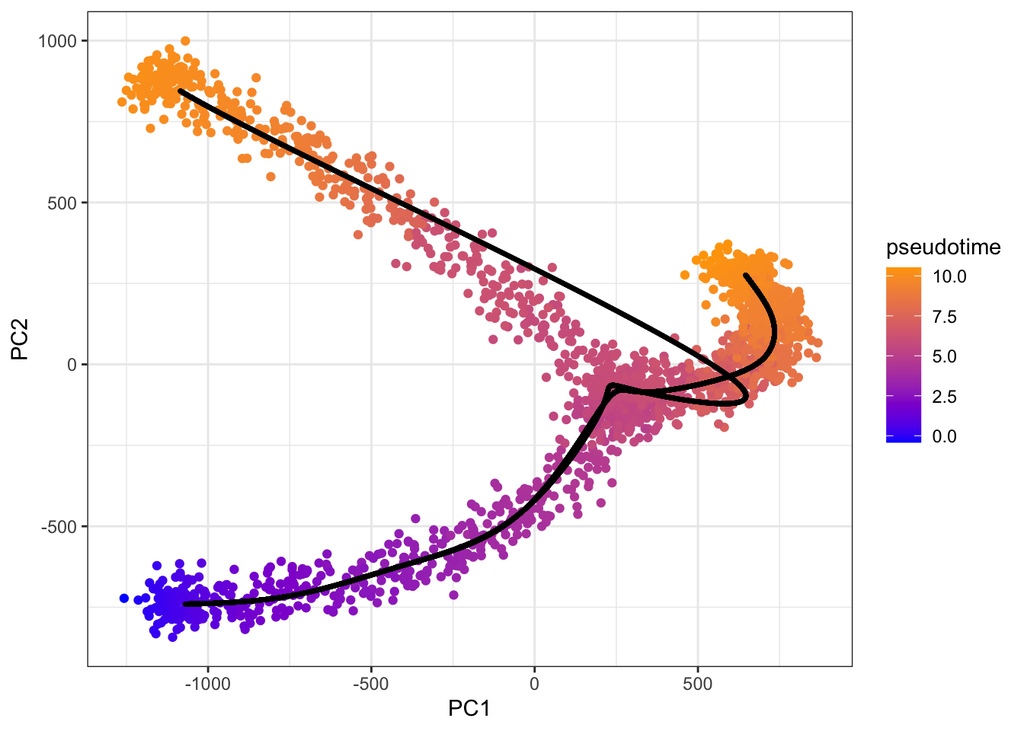

```r
coordinates = retro_obj@coordinates
pseudotime = retro_obj@pseudotime
curves = sapply(retro_obj@RETRO_Curve, "[", 3)

ggplot(as.data.frame(coordinates), aes(x=PC1, y=PC2, colour=pseudotime)) +
  geom_point() +
  scale_colour_continuous(low="blue", high="orange") +
  geom_point(data = as.data.frame(curves[[1]][,1:2]), aes(x = V1, y = V2), size=0.5, colour='black') +
  geom_point(data = as.data.frame(curves[[2]][,1:2]), aes(x = V1, y = V2), size=0.5, colour='black') +
  theme_bw()
```

#### 3.3.2 Density plot

```r
psupertime_density(time, pseudotime)
```

```
#>  [1] 0.2602441 0.2664951 0.2731401 0.2607522 0.2762903 0.2980264 0.2462735
#>  [8] 0.2505740 0.2670106 0.2773697
```

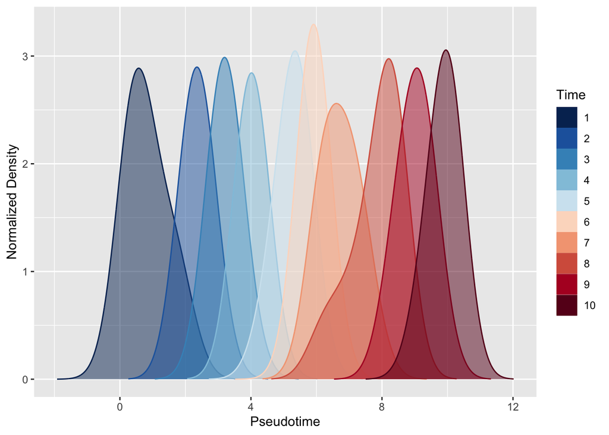